# Simplified_gofull

```python
import os
from pandas import DataFrame
import pandas as pd

import numpy as np
import matplotlib.pyplot as plt
import seaborn as sns
%matplotlib inline

from sklearn import preprocessing
from sklearn.decomposition import PCA
from sklearn.manifold import TSNE

from time import time

from scipy.stats import zscore
from scipy.spatial.distance import pdist
from scipy.spatial.distance import squareform

import umap
```

```python
def preparation(data_path, target_path, fillna=False):
    # load data
    df_raw = pd.read_csv(data_path, index_col=False)
    df_raw = df_raw.set_index(['GO term', 'category', 'description'])

    if fillna == True:
        df_raw = df_raw.fillna(0)
    else:
        df_raw = df_raw.dropna(how='any',axis=0)

        # Sum feature
    df_raw['total'] = df_raw.sum(axis=1) / (len(df_raw.index))

    # Sort feature by sum of numbers
    df_raw = df_raw.sort_values('total', ascending=True)
    df_raw = df_raw.drop(columns=['total'])

    df_raw_target = pd.read_csv(target_path)
    return df_raw, df_raw_target


def normalizing(df_raw, df_raw_target):
    # normalizing by MinMax Scaler
    min_max_scaler = preprocessing.MinMaxScaler()
    scaled_array = min_max_scaler.fit_transform(df_raw)
    df_norm_minmax = pd.DataFrame(scaled_array, columns=df_raw_target.Sample, index=df_raw.index)

    # normalizing by zscore
    df_norm_zscore = df_raw.apply(zscore)

    data_list = [df_raw, df_norm_minmax, df_norm_zscore]

    # Prepare data
    data_raw = df_raw.T
    data_minmax = df_norm_minmax.T
    data_zscore = df_norm_zscore.T


    #target
    y = df_raw_target

    #feature
    x1 = data_raw.values
    x2 = data_minmax.values
    x3 = data_zscore.values

    # Input
    feature = [x1, x2, x3]
    return data_list, feature, y

def calculate_braycurtis(data):
    df = squareform(pdist(data.T, metric='braycurtis'))
    return df

def calculate_PCA(data, y):
    pca = PCA(n_components=3)
    principalComponents = pca.fit_transform(data)
    principalDf = pd.DataFrame(data = principalComponents
             , columns = ['principal component 1', 'principal component 2', 'principal component 3'])
    finalDf = pd.concat([principalDf, pd.DataFrame(y)], axis=1)
    return finalDf

def visualize_PCA_2D(df, hue, legend=True):
    # Set style of scatterplot
    sns.set_context("notebook", font_scale=1.1)
    sns.set_style("whitegrid")

    g = sns.lmplot(x="principal component 1",
               y="principal component 2",
               data=finalDf2,
               legend=True,
               palette="Set2",
               fit_reg=False,
               height=10,
               hue=hue,
               scatter_kws={"s":150, "alpha":0.7})
    plt.title('PCA Results', weight='bold').set_fontsize('14')
    plt.xlabel('Principal Component 1', weight='bold').set_fontsize('10')
    plt.ylabel('Principal Component 2', weight='bold').set_fontsize('10')
    return plt.show()

def plot_heatmap(df, scale):
    plt.figure(figsize = (10,5))
    sns.set(font_scale=0.7)
    #plt.title(title, fontsize =20)
    sns.heatmap(df,
                yticklabels=df.index.get_level_values(2),
                cbar_kws={"orientation": "vertical", 'label': scale})

def calculate_tsne(X, n_components, perplexities, hue):
    tsne_result = []
    for i, perplexity in enumerate(perplexities):
        t0 = time()
        tsne = TSNE(n_components=n_components, init='random',
                         random_state=0, perplexity=perplexity)
        Y = tsne.fit_transform(X)
        tsne_result.append(Y)
        t1 = time()
        print("z-score, perplexity=%d in %.2g sec" % (perplexity, t1 - t0))

        tSNE_df = pd.DataFrame(data = tsne_result[i], columns = ['component_1', 'component_2'])
        tSNE_df = pd.concat([tSNE_df, pd.DataFrame(y)], axis=1)

        # Set style of scatterplot
        sns.set_context("notebook", font_scale=1.1)
        sns.set_style("whitegrid")

        g = sns.lmplot(x="component_1",
               y="component_2",
               data=tSNE_df,
               legend=True,
               palette="Set2",
               fit_reg=False,
               height=10,
               hue=hue,
               scatter_kws={"s":150, "alpha":0.7})
        plt.title('tSNE Result, perplexity= %d'  % (perplexity), weight='bold').set_fontsize('14')
        plt.xlabel('Component 1', weight='bold').set_fontsize('10')
        plt.ylabel('Component 2', weight='bold').set_fontsize('10')
        plt.show()
    return
```

```python
data_path = 'GO_Result/df_raw_GO_Full.csv'
target_path = 'output/df_raw_target.csv'
df_raw, df_raw_target = preparation(data_path, target_path, fillna=True)
df_raw = df_raw.loc[df_raw.index.get_level_values('category') == 'biological_process']
df_raw
```

| GO term | category | description | ERS2431609 | ERS2431610 | ERS2431611 | ERS2431612 | ERS2431613 | ERS2431614 | ERS2431615 | ERS2431616 | ERS2431617 | ERS2431618 | ... | SRS927214 | SRS927215 | SRS927222 | SRS927223 | SRS927224 | SRS927225 | SRS927226 | SRS927227 | SRS927228 | SRS927229 |
| --- | --- | --- | --- | --- | --- | --- | --- | --- | --- | --- | --- | --- | --- | --- | --- | --- | --- | --- | --- | --- | --- | --- | --- |
| GO:0006112 | biological_process | energy reserve metabolic process | 1 | 0.0 | 0.0 | 0.0 | 0.0 | 0.0 | 0.0 | 0.0 | 0.0 | 0.0 | ... | 0.0 | 0.0 | 0.0 | 0.0 | 0.0 | 0.0 | 0.0 | 0.0 | 0.0 | 0.0 |
| GO:0031505 | biological_process | fungal-type cell wall organization | 2 | 0.0 | 0.0 | 0.0 | 0.0 | 1.0 | 0.0 | 0.0 | 0.0 | 0.0 | ... | 0.0 | 0.0 | 0.0 | 0.0 | 0.0 | 0.0 | 0.0 | 0.0 | 0.0 | 0.0 |
| GO:0007269 | biological_process | neurotransmitter secretion | 1 | 0.0 | 0.0 | 0.0 | 0.0 | 0.0 | 0.0 | 0.0 | 0.0 | 0.0 | ... | 0.0 | 0.0 | 0.0 | 0.0 | 0.0 | 0.0 | 0.0 | 0.0 | 0.0 | 0.0 |
| GO:0019856 | biological_process | pyrimidine nucleobase biosynthetic process | 5 | 0.0 | 0.0 | 0.0 | 0.0 | 0.0 | 0.0 | 2.0 | 0.0 | 1.0 | ... | 0.0 | 0.0 | 0.0 | 0.0 | 0.0 | 0.0 | 0.0 | 0.0 | 0.0 | 0.0 |
| GO:0006384 | biological_process | transcription initiation from RNA polymerase III promoter | 1 | 0.0 | 0.0 | 0.0 | 0.0 | 0.0 | 0.0 | 0.0 | 0.0 | 0.0 | ... | 0.0 | 0.0 | 0.0 | 0.0 | 0.0 | 0.0 | 0.0 | 0.0 | 0.0 | 0.0 |
| ... | ... | ... | ... | ... | ... | ... | ... | ... | ... | ... | ... | ... | ... | ... | ... | ... | ... | ... | ... | ... | ... | ... | ... |
| GO:0005975 | biological_process | carbohydrate metabolic process | 56206 | 67349.0 | 72534.0 | 76625.0 | 44479.0 | 99410.0 | 58079.0 | 91582.0 | 94615.0 | 64852.0 | ... | 32.0 | 275.0 | 7060.0 | 125.0 | 1040.0 | 66.0 | 41.0 | 11.0 | 8.0 | 8458.0 |
| GO:0006810 | biological_process | transport | 86323 | 65523.0 | 101034.0 | 85804.0 | 64896.0 | 116569.0 | 97067.0 | 160519.0 | 58346.0 | 97664.0 | ... | 26.0 | 390.0 | 6729.0 | 170.0 | 1878.0 | 86.0 | 33.0 | 8.0 | 8.0 | 10011.0 |
| GO:0006412 | biological_process | translation | 95398 | 105129.0 | 118739.0 | 120395.0 | 78074.0 | 163112.0 | 84901.0 | 163196.0 | 150980.0 | 108884.0 | ... | 26.0 | 368.0 | 8214.0 | 187.0 | 1516.0 | 61.0 | 46.0 | 10.0 | 13.0 | 12226.0 |
| GO:0008152 | biological_process | metabolic process | 241672 | 222768.0 | 282648.0 | 272827.0 | 188713.0 | 369146.0 | 247297.0 | 460089.0 | 262139.0 | 272767.0 | ... | 70.0 | 1199.0 | 20309.0 | 456.0 | 4767.0 | 229.0 | 136.0 | 27.0 | 36.0 | 35226.0 |
| GO:0055114 | biological_process | oxidation-reduction process | 407820 | 374146.0 | 475432.0 | 447914.0 | 334611.0 | 602323.0 | 440314.0 | 670836.0 | 437555.0 | 421545.0 | ... | 160.0 | 1841.0 | 36069.0 | 820.0 | 7961.0 | 314.0 | 201.0 | 57.0 | 52.0 | 56884.0 |

786 rows × 692 columns

```python
data_list, feature, y = normalizing(df_raw, df_raw_target)
```

```python
#null_target_path = 'data/target_merge.csv'
#df_null_target = pd.read_csv(null_target_path)
#df_raw_target = pd.concat([df_raw_target, df_null_target], axis=1, sort=False)
```

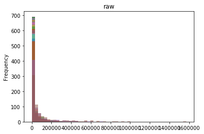

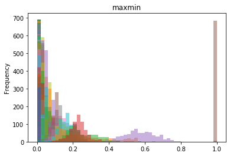

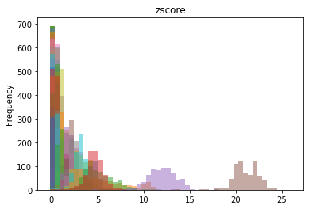

```python
for count, i in enumerate(data_list):
    label = ['raw', 'maxmin', 'zscore']
    select = i.T
    select.plot.hist(bins=50, alpha=0.5, legend=False, title=label[count])
```

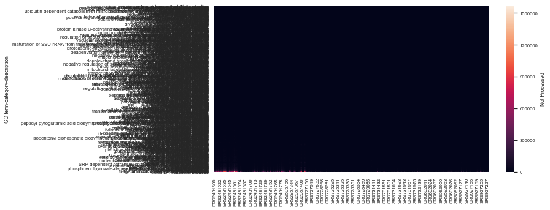

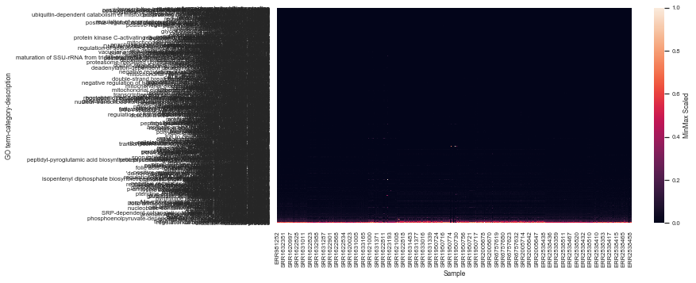

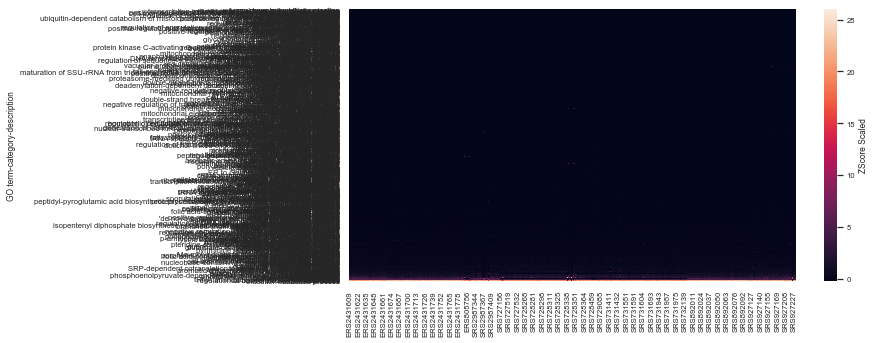

```python
%timeit
dataframe = [[data_list[0], "Not Processed"],
             [data_list[1], "MinMax Scaled"],
             [data_list[2], "ZScore Scaled"],
            ]

for i in dataframe:
    plot_heatmap(i[0], i[1])
```

```
Wall time: 0 ns
```

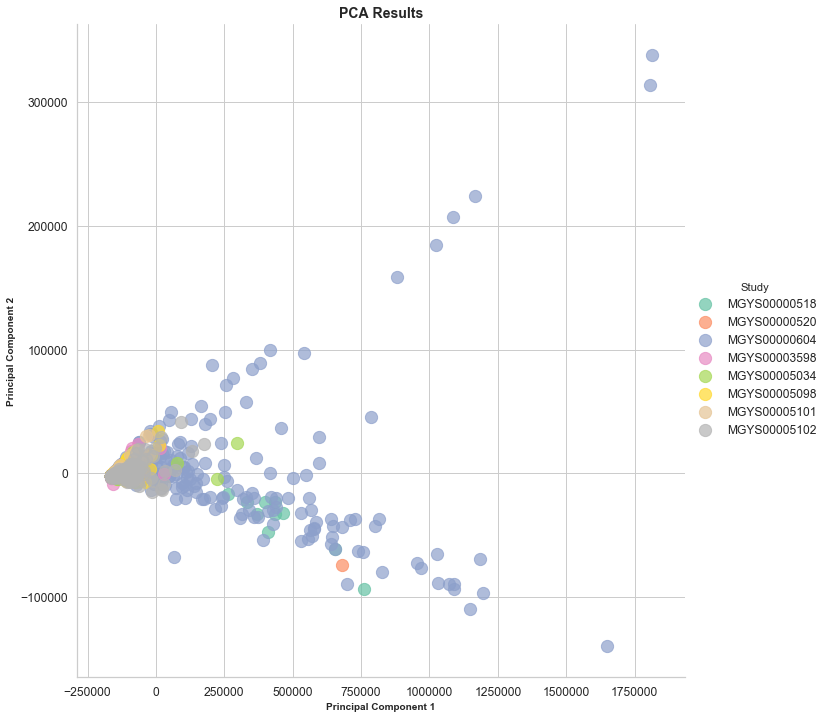

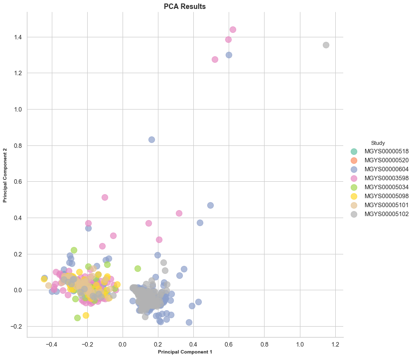

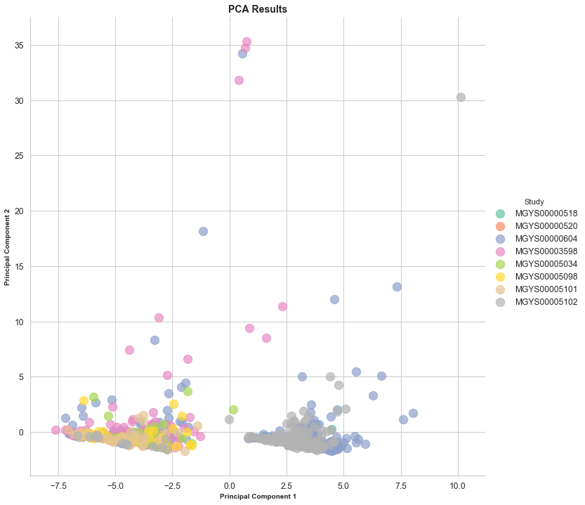

```python
%time
for i in feature:
    finalDf = calculate_PCA(i, y)
    finalDf2 = pd.concat([finalDf, df_null_target], axis=1, sort=False)
    visualize_PCA_2D(finalDf, 'Study')
```

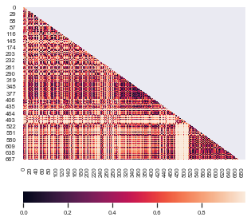

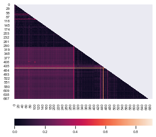

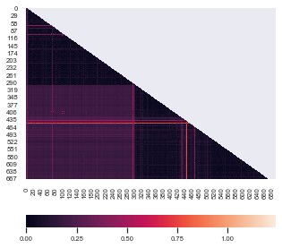

```python
df_braycurtis = []

for i in data_list:
    x = calculate_braycurtis(i)
    df_braycurtis.append(x)

for i in df_braycurtis:
    plt.figure(figsize = (5,5))
    sns.set(font_scale=0.7)
    #plt.title("title", fontsize =20)

    # Generate a mask for the upper triangle
    mask = np.zeros_like(i, dtype=np.bool)
    mask[np.triu_indices_from(mask)] = True

    sns.heatmap(i,
                mask=mask,
                #yticklabels=df.index.get_level_values(2),
                cbar_kws={"orientation": "horizontal"})
```

```
z-score, perplexity=5 in 4.4 sec
```

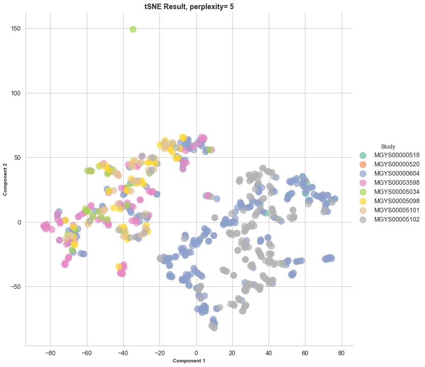

```
z-score, perplexity=25 in 4.5 sec
```

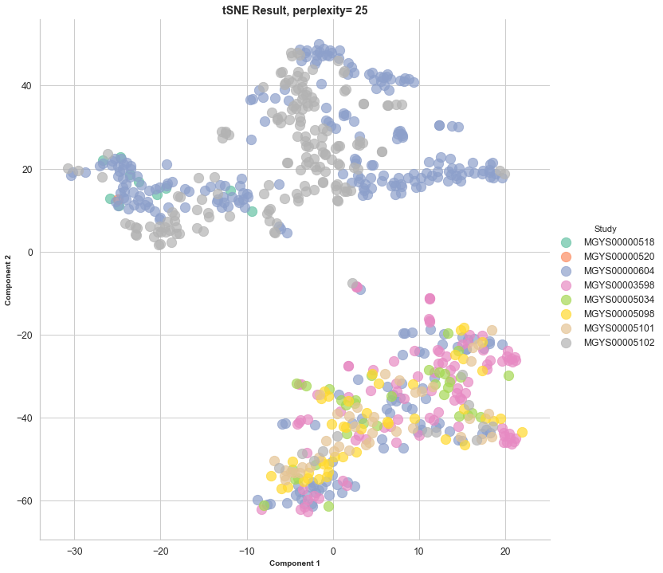

```
z-score, perplexity=50 in 5.3 sec
```

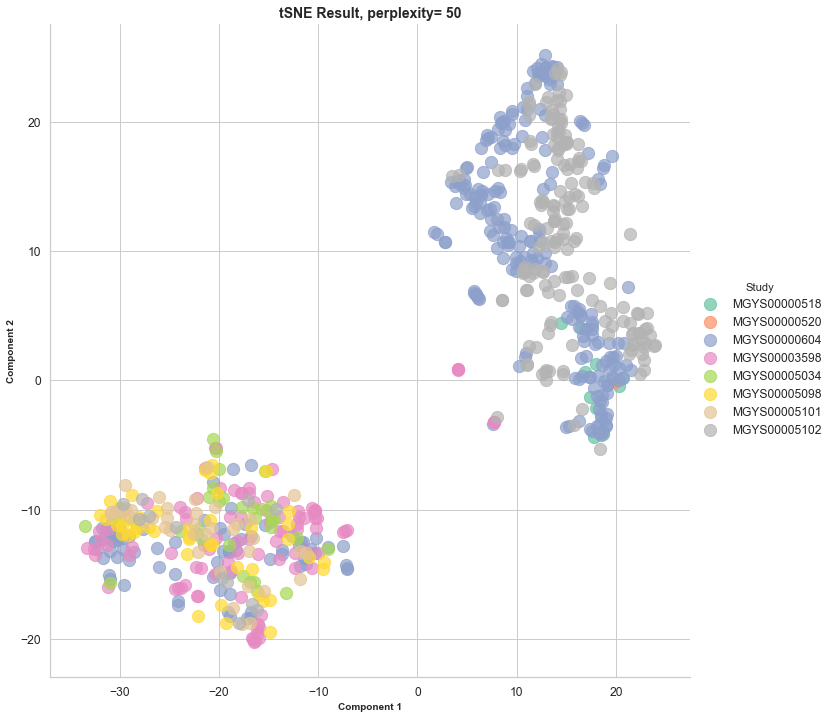

```
z-score, perplexity=100 in 7.7 sec
```

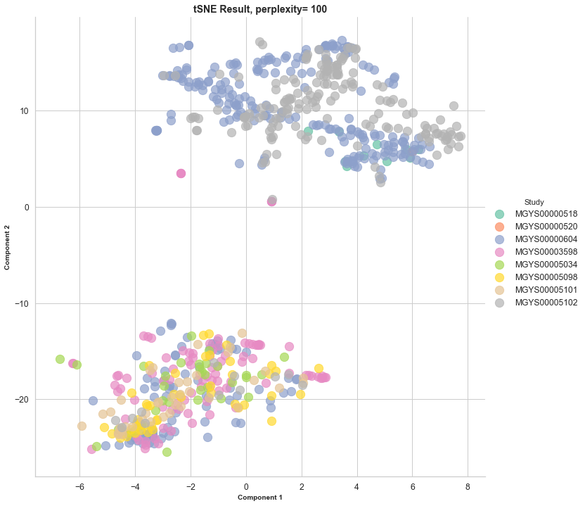

```python
perplexities = [5, 25, 50, 100]
n_components = 2
X = feature[2]
#X = df_braycurtis[2]
hue = 'Study'

calculate_tsne(X, n_components, perplexities, hue)
```

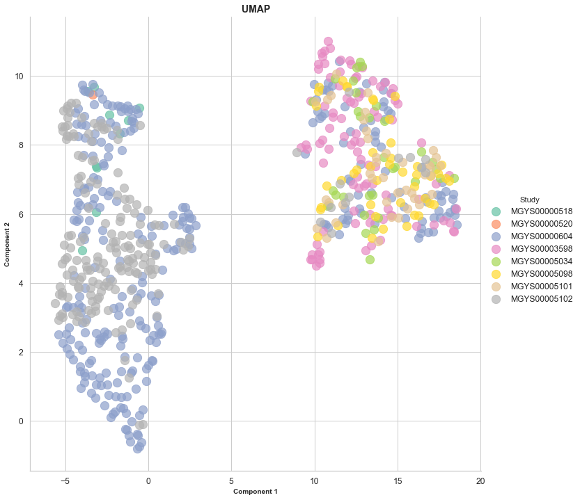

```python
embedding = umap.UMAP(n_neighbors=25,
                      min_dist=0.7,
                      n_components=2,
                      metric='braycurtis').fit_transform(feature[1])
UMAP_df = pd.DataFrame(data = embedding, columns = ['component_1', 'component_2'])
UMAP_df = pd.concat([UMAP_df, pd.DataFrame(y)], axis=1)
sns.set_context("notebook", font_scale=1.1)
sns.set_style("whitegrid")
g = sns.lmplot(x='component_1', y='component_2',
               data=UMAP_df,
               legend=True,
               palette="Set2",
               fit_reg=False,
               height=10,
               hue=hue,
               scatter_kws={"s":150, "alpha":0.7})
plt.title('UMAP', weight='bold').set_fontsize('14')
plt.xlabel('Component 1', weight='bold').set_fontsize('10')
plt.ylabel('Component 2', weight='bold').set_fontsize('10')
plt.show()
```

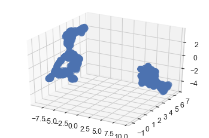

```python
from mpl_toolkits.mplot3d import Axes3D

def draw_umap(data, n_neighbors=15, min_dist=0.1, n_components=3, metric='braycurtis', title=''):
    fit = umap.UMAP(
        n_neighbors=n_neighbors,
        min_dist=min_dist,
        n_components=n_components,
        metric=metric
    )
    u = fit.fit_transform(data);
    fig = plt.figure()
    if n_components == 1:
        ax = fig.add_subplot(111)
        ax.scatter(u[:,0], range(len(u)))
    if n_components == 2:
        ax = fig.add_subplot(111)
        ax.scatter(u[:,0], u[:,1])
    if n_components == 3:
        ax = fig.add_subplot(111, projection='3d')
        ax.scatter(u[:,0], u[:,1], u[:,2], s=100)
    plt.title(title, fontsize=18)

draw_umap(data=feature[2])
```

from sklearn.ensemble import ExtraTreesClassifier

# feature extraction

data_list2, feature2, y2 = normalizing(df_feature_drop, df_raw_target)

df_feature_drop.shape